# R Introduction

2 August 2017

## What is R?

- A Domain-Specific-Language (DSL) for statistics and data analysis
- Based on the S Programming Language
- An environment for Exploratory Data Analysis (EDA)
- A quasi-functional language with IDE and REPL
- A vectorized language with BLAS support
- A collection of over 7,000+ libraries
- A large and active community across industry and academia
- Around 20 years old (Lineage dates from 1975 - almost 40 years ago)

## Types

- Primitives (numeric, integer, character, logical, factor)
- Data Frames
- Lists
- Tables
- Arrays
- Environments
- Others (functions, closures, promises..)

## Simple Types

```r
x <- 1
class(x)
## [1] "numeric"

y <- "Hello World"
class(y)
## [1] "character"

z <- TRUE
class(z)
## [1] "logical"

as.integer(z)
## [1] 1
```

## Simple Types - Vectors

The basic type unit in R is a vector

```r
x <- c(1,2,3)
x
## [1] 1 2 3
x <- 1:3
x[1]
## [1] 1
x[0]
## integer(0)
x[-1]
## [1] 2 3
```

## Generating Vectors

R provides lots of convenience functions for data generation:

```r
rep(0, 5)
## [1] 0 0 0 0 0
seq(1,10)
##  [1]  1  2  3  4  5  6  7  8  9 10
seq(1,2,.1)
##  [1] 1.0 1.1 1.2 1.3 1.4 1.5 1.6 1.7 1.8 1.9 2.0
seq(1,2,length.out=6)
## [1] 1.0 1.2 1.4 1.6 1.8 2.0
```

## Indexing

```r
x <- c(1, 3, 4, 10, 15, 20, 50, 1, 6)
x > 10
## [1] FALSE FALSE FALSE FALSE  TRUE  TRUE  TRUE FALSE FALSE
which(x > 10)
## [1] 5 6 7
x[x>10]
## [1] 15 20 50
x[!x>10]
## [1]  1  3  4 10  1  6
x[x<=10]
## [1]  1  3  4 10  1  6
x[x>10 & x<30]
## [1] 15 20
```

## Functions

```r
square <- function(x) x^2
square(2)
## [1] 4

pow <- function(x, p=2) x^p
pow(10)
## [1] 100
pow(10,3)
## [1] 1000
pow(p=3,10)
## [1] 1000
```

Functions can be passed as data:

```r
g <- function(x, f) f(x)
g(10, square)
## [1] 100

h <- function(x,f,...) f(x,...)
h(10, pow, 3)
## [1] 1000
```

## R is Vectorized

Example - multiplying two vectors:

```r
mult <- function(x,y) {
 z <- numeric(length(x))
 for (i in 1:length(x)) {
    z[i] <- x[i] * y[i]
 }
 z
}

mult(1:10,1:10)
```

```
##  [1]   1   4   9  16  25  36  49  64  81 100
```

## R is Vectorized

Multiplying two vectors 'the R way':

```r
1:10 * 1:10
```

```
##  [1]   1   4   9  16  25  36  49  64  81 100
```

NOTE: R recycles vectors of unequal length:

```r
1:10 * 1:2
```

```
##  [1]  1  4  3  8  5 12  7 16  9 20
```

## NOTE: Random Number Generation

R contains a huge number of built-in random number generators for various probability distributions

```r
# Normal variates, mean=0, sd=1
rnorm(10)
```

```
##  [1] -0.304845 -0.097306 -0.208658 -0.628885 -0.434207 -0.365301  0.297167
##  [8] -0.551593 -1.438303  0.792028
```

```r
rnorm(10, mean=100, sd=5)
```

```
##  [1] 105.561 106.165 107.083 103.918  97.948  99.119 106.423 104.081
##  [9]  98.208 103.086
```

Many different distributions available (the **r*** functions)

## Data Frames

- Data frames are the fundamental structure used in data analysis
- Similar to a database table in spirit (named columns, distinct types)

```r
d <- data.frame(x=1:6, y="AUDUSD", z=c("one","two"))
d
```

```
##   x      y   z
## 1 1 AUDUSD one
## 2 2 AUDUSD two
## 3 3 AUDUSD one
## 4 4 AUDUSD two
## 5 5 AUDUSD one
## 6 6 AUDUSD two
```

## Data Frames

Data frames can be indexed like a vector or matrix:

```r
# First row
d[1,]
##   x      y   z
## 1 1 AUDUSD one

# First column
d[,1]
## [1] 1 2 3 4 5 6

# First and third cols, first two rows
d[1:2,c(1,3)]
##   x   z
## 1 1 one
## 2 2 two
```

## Data Frames

Let's generate some dummy data:

```r
generateData <- function(N) data.frame(time=Sys.time()+1:N,
  sym="AUDUSD",
  bid=rep(1.2345,N)+runif(min=-.0010,max=.0010,N),
  ask=rep(1.2356,N)+runif(min=-.0010,max=.0010,N),
  exch=sample(c("EBS","RTM","CNX"),N, replace=TRUE))

prices <- generateData(50)
head(prices, 5)
```

```
##                      time    sym    bid    ask exch
## 1 2018-01-29 21:07:21.121 AUDUSD 1.2340 1.2346  EBS
## 2 2018-01-29 21:07:22.121 AUDUSD 1.2346 1.2346  RTM
## 3 2018-01-29 21:07:23.121 AUDUSD 1.2342 1.2365  EBS
## 4 2018-01-29 21:07:24.121 AUDUSD 1.2354 1.2363  EBS
## 5 2018-01-29 21:07:25.121 AUDUSD 1.2342 1.2355  EBS
```

## Data Frames

We can add/remove columns on the fly:

```r
prices$spread <- prices$ask-prices$bid
prices$mid <- (prices$bid + prices$ask) * 0.5
head(prices)
```

```
##                      time    sym    bid    ask exch     spread    mid
## 1 2018-01-29 21:07:21.121 AUDUSD 1.2340 1.2346  EBS 6.4751e-04 1.2343
## 2 2018-01-29 21:07:22.121 AUDUSD 1.2346 1.2346  RTM 2.4804e-05 1.2346
## 3 2018-01-29 21:07:23.121 AUDUSD 1.2342 1.2365  EBS 2.3011e-03 1.2353
## 4 2018-01-29 21:07:24.121 AUDUSD 1.2354 1.2363  EBS 9.1662e-04 1.2358
## 5 2018-01-29 21:07:25.121 AUDUSD 1.2342 1.2355  EBS 1.3264e-03 1.2349
## 6 2018-01-29 21:07:26.121 AUDUSD 1.2341 1.2359  EBS 1.8240e-03 1.2350
```

## Data Frames

Some basic operations on data frames:

```r
names(prices)
## [1] "time"   "sym"    "bid"    "ask"    "exch"   "spread" "mid"

table(prices$exch)
##
## CNX EBS RTM
##  14  17  19

summary(prices$mid)
##    Min. 1st Qu.  Median    Mean 3rd Qu.    Max.
##    1.23    1.23    1.24    1.24    1.24    1.24
```

## Data Frames

Operations can be applied across different dimensions of a data frame:

```r
sapply(prices,class)
## $time
## [1] "POSIXct" "POSIXt"
##
## $sym
## [1] "factor"
##
## $bid
## [1] "numeric"
##
## $ask
## [1] "numeric"
##
## $exch
## [1] "factor"
##
## $spread
## [1] "numeric"
##
## $mid
## [1] "numeric"
```

## Aggregations and Rollups

Aggregation and rollups:

```r
tapply(prices$spread, prices$exch, mean)
```

```
##        CNX        EBS        RTM
## 0.00103518 0.00114388 0.00097074
```

## Aggregations and Rollups

```r
tapply(prices$mid, prices$exch, function(x) diff(log(x)))
```

```
## $CNX
##  [1]  2.9732e-04  7.1905e-06  3.2557e-04 -5.4264e-04 -2.2490e-04
##  [6]  1.1830e-03 -9.9899e-04 -3.3265e-05  1.9254e-04  6.1899e-04
## [11] -8.5781e-04  6.3875e-04 -6.6610e-04
##
## $EBS
##  [1]  8.4076e-04  4.1654e-04 -7.8628e-04  9.8971e-05  2.0484e-04
##  [6]  2.3932e-04 -4.9766e-04  4.0255e-04 -3.5627e-04  1.8239e-04
## [11]  6.4982e-04 -7.9168e-04  1.5645e-04 -5.1928e-04  2.4624e-04
## [16] -3.5619e-04
##
## $RTM
##  [1]  1.3731e-05  4.2084e-04  2.2599e-04 -1.2774e-04 -6.2287e-05
##  [6] -6.9015e-04  3.6897e-04  4.3586e-05  5.8125e-04 -3.2986e-04
## [11] -4.3243e-04  4.8014e-04  3.1011e-04 -6.4789e-04  2.0489e-04
## [16]  2.0154e-04 -4.0936e-04  2.1597e-04
```

## Aggregations and Rollups

Aggregating summary statistics by time:

```r
aggregate(prices[,c("bid","ask")],
  by=list(bucket=cut(prices$time, "10 sec")), mean)
```

```
##                    bucket    bid    ask
## 1 2018-01-29 21:07:21.121 1.2345 1.2356
## 2 2018-01-29 21:07:31.121 1.2345 1.2356
## 3 2018-01-29 21:07:41.121 1.2347 1.2356
## 4 2018-01-29 21:07:51.121 1.2346 1.2359
## 5 2018-01-29 21:08:01.121 1.2345 1.2353
```

## Aggregations and Rollups

```r
aggregate(prices[,c("bid","ask")],
          by=list(bucket=cut(prices$time, "10 sec")),
          function(x) c(min=min(x),max=max(x)))
```

```
##                    bucket bid.min bid.max ask.min ask.max
## 1 2018-01-29 21:07:21.121  1.2336  1.2354  1.2346  1.2365
## 2 2018-01-29 21:07:31.121  1.2337  1.2353  1.2348  1.2365
## 3 2018-01-29 21:07:41.121  1.2341  1.2354  1.2349  1.2363
## 4 2018-01-29 21:07:51.121  1.2335  1.2355  1.2352  1.2366
## 5 2018-01-29 21:08:01.121  1.2337  1.2354  1.2348  1.2365
```

## Aggregations and Rollups

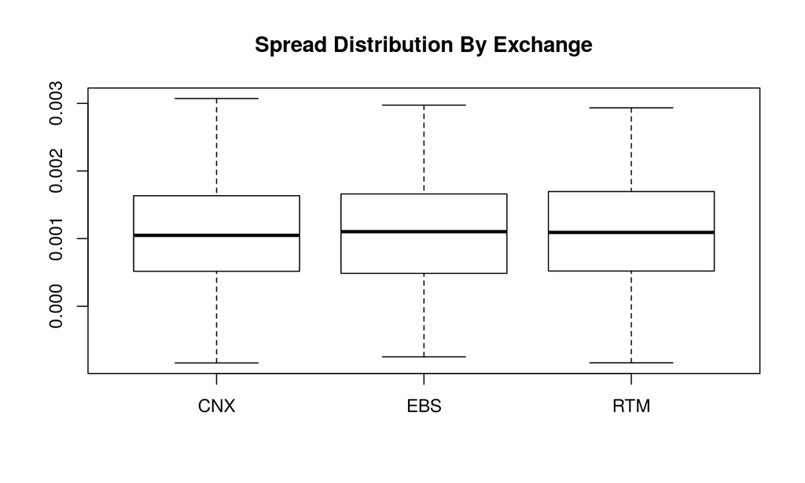

```r
prices <- generateData(2000)
prices$spread <- prices$ask-prices$bid
boxplot(prices$spread ~ prices$exch, main="Spread Distribution By Exchange")
```

## Closures

R functions contain a reference to the enclosing environment:

```r
add <- function(x) {
 function(y) x + y
}

increment <- add(1)
increment(2)
```

```
## [1] 3
```

## R's Lisp Influence

R is heavily influenced by Lisp/Scheme

cf. "Structure And Interpretation of Computer Programs"

[figure not shown]

## R's Lisp Influence

```r
`+`(2,3)
```

```
## [1] 5
```

```r
(`*` (2, (`+`(2,3))))
```

```
## [1] 10
```

```r
codetools::showTree(quote(2*(2+3)))
```

```
## (* 2 ("(" (+ 2 3)))
```

## R's Lisp Influence

Also evident in the underlying C code:

```c
SEXP attribute_hidden do_prmatrix(SEXP call, SEXP op,
  SEXP args, SEXP rho)
{
    int quote;
    SEXP a, x, rowlab, collab, naprint;
    char *rowname = NULL, *colname = NULL;

    checkArity(op,args);
    PrintDefaults();
    a = args;
    x = CAR(a); a = CDR(a);
    rowlab = CAR(a); a = CDR(a);
    collab = CAR(a); a = CDR(a);

    quote = asInteger(CAR(a)); a = CDR(a);
```

## Operators Are Functions

```r
`(`
```

```
## .Primitive("(")
```

```r
(1+2)
```

```
## [1] 3
```

```r
`(` <- function(x) 42
(1+2)
```

```
## [1] 42
```

```r
rm("(")
```

## Example: Median Absolute Deviation

\(MAD(x) = median\left(\left|Y_i - \hat{Y}\right|\right)\)

```r
mad
```

```
## function (x, center = median(x), constant = 1.4826, na.rm = FALSE,
##     low = FALSE, high = FALSE)
## {
##     if (na.rm)
##         x <- x[!is.na(x)]
##     n <- length(x)
##     constant * if ((low || high) && n%%2 == 0) {
##         if (low && high)
##             stop("'low' and 'high' cannot be both TRUE")
##         n2 <- n%/%2 + as.integer(high)
##         sort(abs(x - center), partial = n2)[n2]
##     }
##     else median(abs(x - center))
## }
## <bytecode: 0x4656628>
## <environment: namespace:stats>
```

## Example: Median Absolute Deviation

Shows: lazy evaluation, filering, logical casting, if/else return values, partial sorting

```
function (x, center = median(x), constant = 1.4826, na.rm = FALSE,
    low = FALSE, high = FALSE)
{
    if (na.rm) x <- x[!is.na(x)]
    n <- length(x)
    constant * if ((low || high) && n%%2 == 0) {
        if (low && high)
            stop("'low' and 'high' cannot be both TRUE")
        n2 <- n%/%2 + as.integer(high)
        sort(abs(x - center), partial = n2)[n2]
    }
    else median(abs(x - center))
}
```

## Example: Simulating Coin Tosses

What is the probability of exactly 3 heads in 10 coin tosses for a fair coin?

*Using binomial identity:* \(\binom{n}{k}p^{k}(1-p)^{(n-k)} = \binom{10}{3}\left(\frac{1}{2}\right)^{3}\left(\frac{1}{2}\right)^{7}\)

```r
choose(10,3)*(.5)^3*(.5)^7
```

```
## [1] 0.11719
```

*Using binomial distribution density function:*

```r
 dbinom(prob=0.5, size=10, x=3)
```

```
## [1] 0.11719
```

*Using simulation (100,000 tosses):*

```r
sum(replicate(100000,sum(rbinom(prob=1/2, size=10, 1))==3))/100000
```

```
## [1] 0.11658
```

## Example: Random Walk

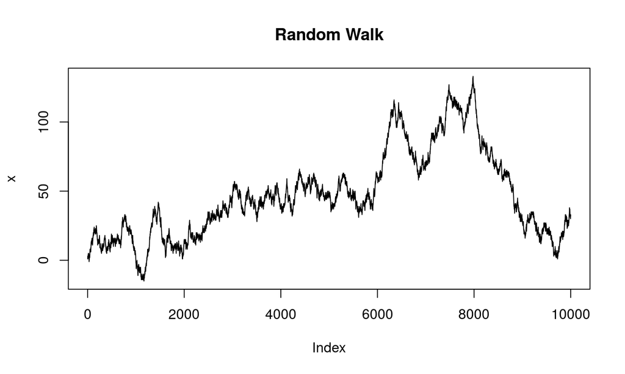

```r
x<-(cumsum(ifelse(rbinom(prob=0.5, size=1, 10000)==0,-1,1)))
plot(x, type='l', main='Random Walk')
```

## Example: Generating Random Data

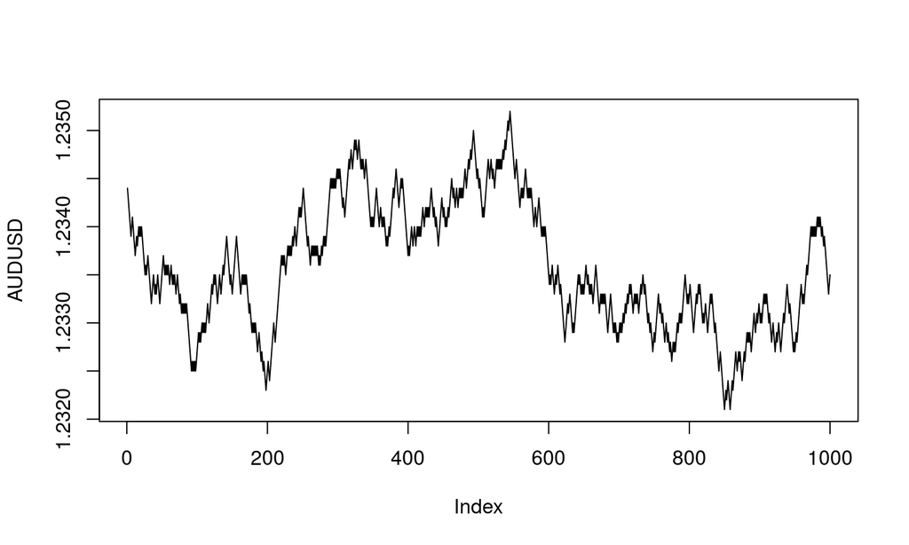

```r
randomWalk <-function(N)(cumsum(ifelse(rbinom(prob=0.5, size=1, N)==0,-1,1)))
AUDUSD <- 1.2345 + randomWalk(1000)*.0001
plot(AUDUSD, type='l')
```

## Example: OANDA FX Data

```r
require(quantmod);require(TTR)
EURUSD <- getSymbols("EUR/USD", src="oanda", auto.assign=FALSE)
plot(EURUSD)
lines(EMA(EURUSD,10), col='red')
lines(EMA(EURUSD,30), col='blue')
```

[figure not shown]

## Example: Connecting to kdb+

[output not shown]

## Example: Connecting to kdb+

```r
setwd("/Users/rorywinston/sandbox/kdb")
source("qserver.R")
open_connection("localhost", 5000)
trades <- k("select from trades")
head(trades)
                 time     price side exch    sym
1 2010-08-13 22:33:29 0.6019404    B  CNX EURUSD
2 2001-11-25 07:53:58 0.7075032    S  CNX EURUSD
3 2002-12-12 14:12:04 1.5008982    S  CNX GBPUSD
4 2002-02-13 08:48:33 0.6170263    S  EBS AUDUSD
5 2014-05-01 16:59:44 0.8821325    S  EBS GBPUSD
6 2010-12-07 02:30:14 1.0946771    S  RTM AUDUSD
```

kdb+ datatypes are converted to native R types

## Example: Reading Log Data From File

```r
# Read file into data frame
logfile <- read.csv("/tmp/application.log", sep=",", header=FALSE)
# Set column descriptors
colnames(logfile) <- c("time","message","severity")
# Convert to native date/time
logfile$time <- as.POSIXct(strptime
                  (logfile$time, "%Y-%m-%d %H:%M:%OS"), tz="GMT")
```

## Example: Using Datasets

The famous 'Air passengers' dataset

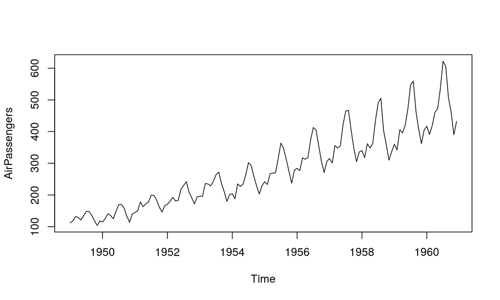

```r
plot(AirPassengers)
```

## Example: Using Datasets

The 'Anscombe Quartet' dataset

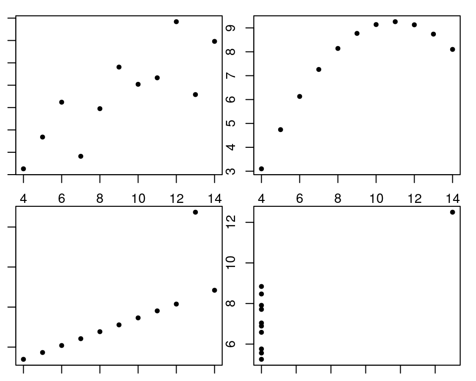

```r
op <- par(mfrow=c(2,2),mar=rep(1,4))
with(anscombe,{plot(x1,y1,pch=20);plot(x2,y2,pch=20);
               plot(x3,y3,pch=20);plot(x4,y4,pch=20)})
```

```r
par(op)
```

## Recommended Libraries

- ggplot2 - Mini-DSL for data visualization
- zoo/xts - Time series libraries
- Matrix - Enhanced matrix library
- plyr/reshape - Data reshaping/manipulation
- data.table - Faster data.frame manipulation
- e1071 - Machine learning/data mining functions
- caret - Statistical learning/training functions
- randomforest - Random forest library
- Rcpp - Convenient C++ interface

## Other Topics (Not Covered)

- S3/S4 Classes/Objects
- Packages
- Lazy Evaluation
- Formula Interface
- JIT Compilation/bytecode
- Debugging
- C/C++ Interfaces
- Reproducible Research (Sweave/knitr/markdown)

## Links

http://www.r-project.org